# Lab 7

## Introduction

We will be doing the event selection optimization to increase the significance of our Higgs measurement for the dataset with lower pT(transverse momentum) samples for this lab.

## About the Data

The LHC produces around 1 billion events per second which is comparable to the speed of a CPU in a computer. This is great as it means that the computer can process the events - just barely - however the storage required to record an event is around 1 MB which, for 1 billion events, is not feasible. Instead, about 200 MB of data is written per second thus only about 100 to 200 of the 1 billion events are recorded. In order to determine which data to write and which data to throw away a triggering system is put in place - informed by the physical event that is trying to be observed. This system will result in recording events that satisfy a list of criteria. We could imagine one possible criteria would be for the mass of the particle observed to be around 125 Gev/c^2 if we were searching for the Higgs Boson.

$yield_{higgs} = N_{higgs} * R_{higgs}$

$yield_{qcd} = N_{qcd} * R_{qcd}$

$N_{higgs}$, number of higgs simulated events

$N_{qcd}$, number of qcd simulated events

#### Downloading the Data

```python
%matplotlib inline
import numpy as np
import matplotlib
import matplotlib.pyplot as plt
import scipy
from scipy import stats
import h5py
import pickle
plt.rcParams["figure.figsize"] = (12,8)
```

```python
infile_qcd = open("qcd_100000_pt_250_500.pkl",'rb')
qcd_data = pickle.load(infile_qcd)
infile_higgs = open("higgs_100000_pt_250_500.pkl", 'rb')
higgs_data = pickle.load(infile_higgs)
```

## Problem 1 - Evaluating the expected significance without any event selection

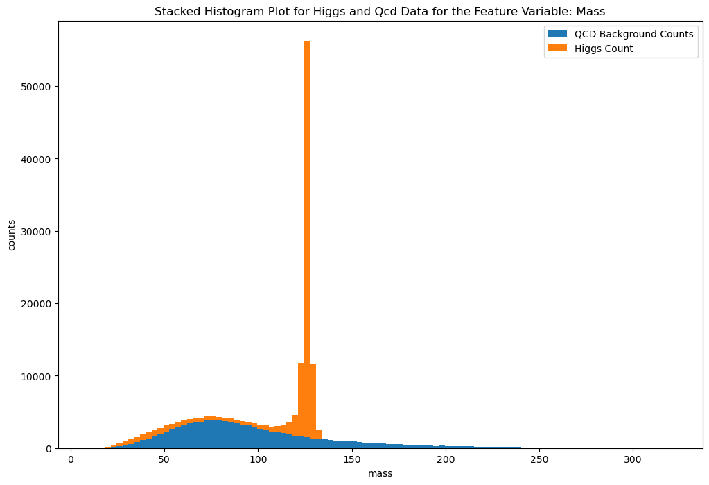

```python
data = [qcd_data["mass"], higgs_data["mass"]]
plt.hist(data, bins = 100, stacked = True, label = ["QCD Background Counts", "Higgs Count"])
plt.ylabel("counts")
plt.xlabel("mass")
plt.legend()
plt.title("Stacked Histogram Plot for Higgs and Qcd Data for the Feature Variable: Mass")
plt.show()
```

We can see that Higgs data has a smaller range of data points for different mass values compared to the QCD Background data. For the Higgs count distributon the mass of events lie within the approx range of 10 GeV/C^2 to 140 GeV/c^2.For the QCD Background count distributon the mass of events lie within the approx range of 10 GeV/C^2 to 280 GeV/c^2.

#### Calculating Significance

To calculate the significance we will answer the following question:

What is the significance of getting a signal of 20100 (n_higgs + n_qcd) provided a QCD background of poisson distribution with parameter as 20000?

Our background is Poisson distribution so we will use Poisson statistics for the significance calculation.

```python
probability = stats.poisson.sf(20100, 20000)
sig = stats.norm.isf(probability)
sig
```

```
0.7112259282313185
```

#### Comparing the exact significance to the approximation

The significance of getting 20100 jets is .711

NHiggs/sqrt(NQCD) = 100/sqrt(20000) = 0.707

We can see that the value of the exact significance is very close to the value of the approximation. However they are not exactly the same. This is because according to the Central Limit Theorem when the parameter of the Poisson distribution gets large the Poisson distribution behaves more like a Gaussian distribution with standard deviation equal to the root of the parameter of Poisson distribution.

The parameter for our background Poisson distribution is n_qcd, thus the standard deviation of our approximate Gaussian is sqrt(n_qcd).

Now as the mean of this Poisson distribution, and thus Gaussian distribution is n_qcd we know that our signal n_qcd + n_higgs is simply the mean value of the distribution plus n_higgs.

To get how many standard deviations the n_higgs is from the mean we divide n_higgs by the standard deviation.Thus we get n_higgs/sqrt(n_qcd).

Thusthe value of the exact significance is very close to the value of the approximation.The value does not exactly match as pisson distribution only approaches the Gaussian distribution as its parameter increases it will never be exactly Gaussian distribution.

## Problem2 - mass cuts to optimize the expected significance.

To find the best cut let's start with making 3 cuts. And calculating the significance of the signal after making the 3 cuts.

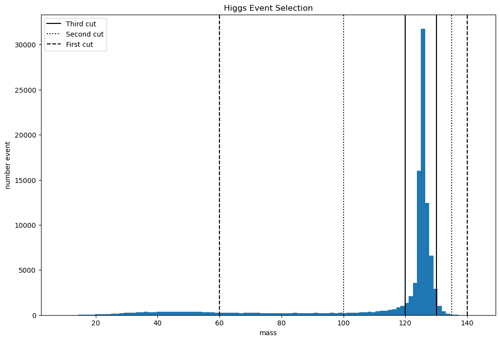

```python
plt.hist(higgs_data["mass"], bins = 100)
plt.axvline(120, linestyle='-', c='k', label='Third cut')
plt.axvline(130, linestyle='-', c='k')
plt.axvline(100, linestyle=':', c='k', label='Second cut')
plt.axvline(135, linestyle=':', c='k')
plt.axvline(140, linestyle='--', c='k', label='First cut')
plt.axvline(60, linestyle='--', c='k')
plt.title("Higgs Event Selection")
plt.xlabel("mass")
plt.ylabel("number event")
plt.legend()
plt.show()
```

```python
higgs_cut1 = higgs_data[(higgs_data["mass"]>= 60) & (higgs_data["mass"] <= 140)]
```

```python
qcd_cut1 = qcd_data[(qcd_data["mass"] >= 60) & (qcd_data["mass"] <= 140)]
```

```python
higgs_cut2 = higgs_data[(higgs_data["mass"]>= 100) & (higgs_data["mass"] <= 135)]
```

```python
qcd_cut2 = qcd_data[(qcd_data["mass"] >= 100) & (qcd_data["mass"] <= 135)]
```

```python
higgs_cut3 = higgs_data[(higgs_data["mass"]>= 120) & (higgs_data["mass"] <= 130)]
```

```python
qcd_cut3 = qcd_data[(qcd_data["mass"] >= 120) & (qcd_data["mass"] <= 130)]
```

#### For the First Cut

count of higg events after the cut:

```python
cnt_higgs1 = len(higgs_cut1) * (.001)
cnt_higgs1
```

```
91.58800000000001
```

count of qcd events after the cut:

```python
cnt_qcd1 = len(qcd_cut1) * (.2)
cnt_qcd1
```

```
13484.800000000001
```

Probability of Signal

```python
p = stats.poisson.sf(cnt_higgs1 + cnt_qcd1, mu = cnt_qcd1)
p
```

```
0.21470146201092905
```

Significance of the signal:

```python
stats.norm.isf(p)
```

```
0.7902137897831116
```

#### For the Second Cut

count of higg events after the cut:

```python
cnt_higgs2 = len(higgs_cut2) * (.001)
cnt_higgs2
```

```
84.894
```

```python
cnt_qcd2 = len(qcd_cut2) * (.2)
cnt_qcd2
```

```
4189.0
```

Probability of Signal

```python
p = stats.poisson.sf(cnt_higgs2 + cnt_qcd2, mu = cnt_qcd2)
p
```

```
0.09615296039870802
```

Significance of the signal:

```python
stats.norm.isf(p)
```

```
1.303787866351245
```

#### For the Third Cut

count of higg events after the cut:

```python
cnt_higgs3 = len(higgs_cut3) * (.001)
cnt_higgs3
```

```
75.84700000000001
```

```python
cnt_qcd3 = len(qcd_cut3) * (.2)
cnt_qcd3
```

```
980.2
```

Probability of Signal

```python
p = stats.poisson.sf(cnt_higgs3 + cnt_qcd3, mu = cnt_qcd3)
p
```

```
0.007939417435556121
```

Significance of the signal:

```python
stats.norm.isf(p)
```

```
2.411688648925926
```

The third cut that gave us the maximum significance with mass >= 120 GeV/c^2 and mass <= 130 GeV/c^2

#### For the best cut:

The significance : 2.411688648925926

Percent of higgs data eliminated

```python
100 - ((len(higgs_cut3)/len(higgs_data)) * 100)
```

```
24.153000000000006
```

Percent of qcd data eliminated

```python
100 - ((len(qcd_cut3)/len(qcd_data)) * 100)
```

```
95.099
```

Eventhough our significance improved from 0.711 to 2.412. It is still not enough to confirm a signal, to confirm our signal we need a significance of 5 or greater.

## Problem 3 - Exploring rest of the features through stacked Histograms

We will make two sets of stacked histogram plots - 1 without any event selection, 1 with optimal mass cuts for the rest of the features.We will use the 1st plot to identify another feature as discriminative as mass, the other to identify another feature to further improve our expected signifiance

```python
def plot_stacked(feature):
    bins = 100
    qcd_feature_data = qcd_data[feature]
    higgs_feature_data = higgs_data[feature]
    feature_data = [qcd_data[feature], higgs_data[feature]]

    qcd_feature_cut_data = qcd_cut3[feature]
    higgs_feature_cut_data = higgs_cut3[feature]
    feature_cut_data = [qcd_cut3[feature], higgs_cut3[feature]]

    plt.suptitle('Stacked QCD background for ' + feature)
    # Without cutting data
    plt.subplot(2, 1, 1)
    plt.hist(feature_data, bins=100, stacked=True, label=['QCD Background counts', 'Higgs counts'])
    plt.title('Stacked QCD background counts and Higgs counts')
    plt.xlabel(f' {feature}')
    plt.ylabel('Event counts')
    plt.legend()

    plt.show()

    # After slicing
    plt.subplot(2, 2, 1)
    plt.hist(feature_cut_data, bins=100, stacked=True, label=['QCD Background counts', 'Higgs counts'])
    plt.title('Stacked QCD background counts and Higgs counts cut at mass')
    plt.xlabel(f' {feature}')
    plt.ylabel('Event counts')
    plt.legend()
    plt.show()
```

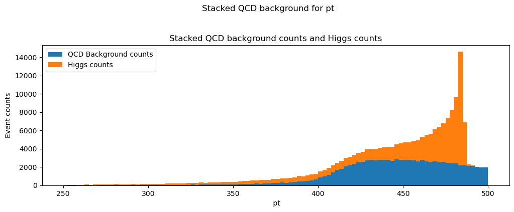

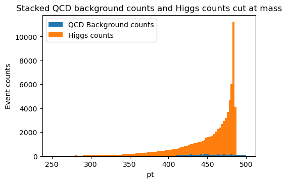

```python
plot_stacked("pt")
```

From the 1st plot we can see that both the background data and the Higgs data have a similar spread this is not a discriminative feature as a cut on this feature would not be productive as it would throw out more Higgs than background.

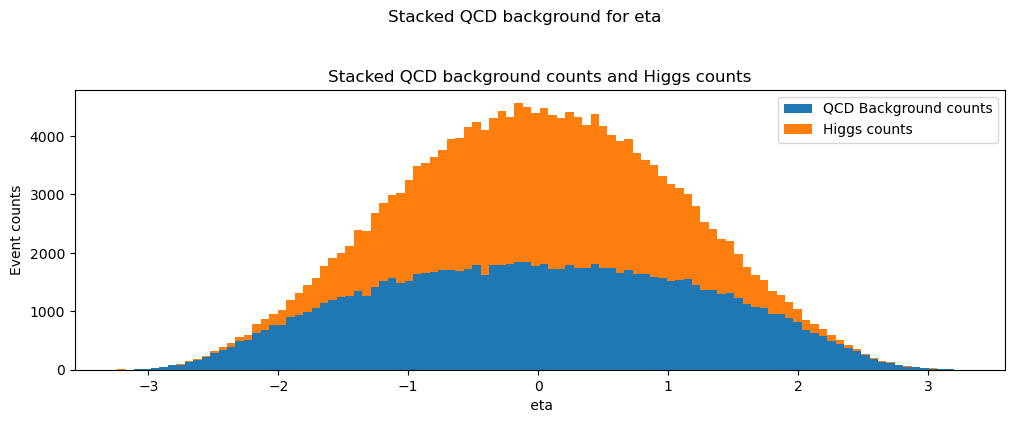

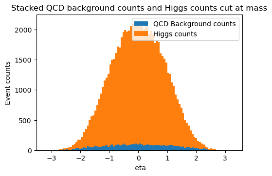

```python
plot_stacked("eta")
```

From the 1st plot we can see that both the background data and the Higgs data have a similar spread this is not a discriminative feature as a cut on this feature would not be productive as it would throw out more Higgs than background.

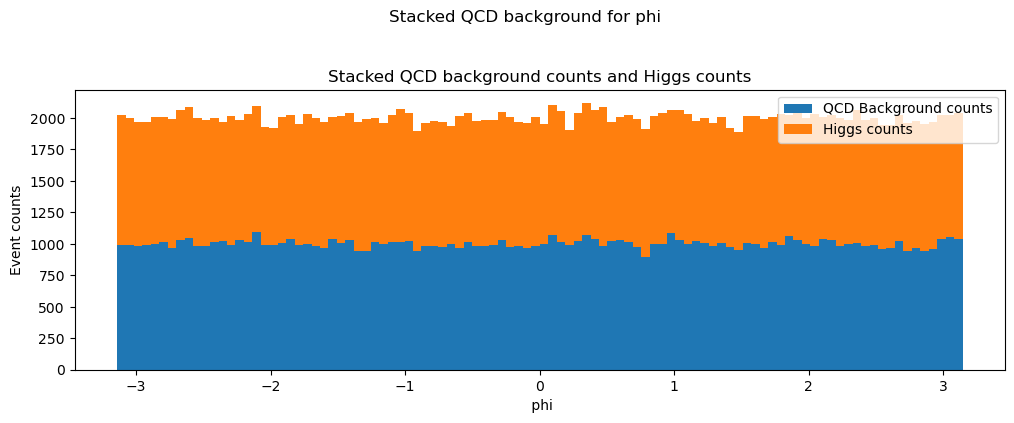

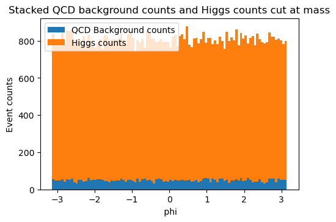

```python
plot_stacked("phi")
```

From the 1st plot we can see that both the background data and the Higgs data have a similar spread this is not a discriminative feature as a cut on this feature would not be productive as it would throw out more Higgs than background.

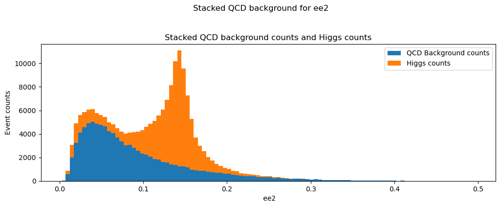

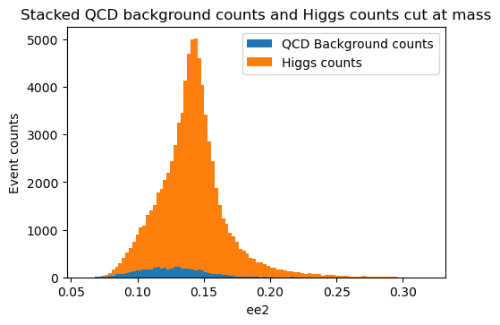

```python
plot_stacked("ee2")
```

Looking at the 1st plot we can infer that ee2 could have bean a desirable split (but not as good as mass) before the cut at mass.After the cut at mass there is very little room to eliminate the background data without eliminating the higgs data.

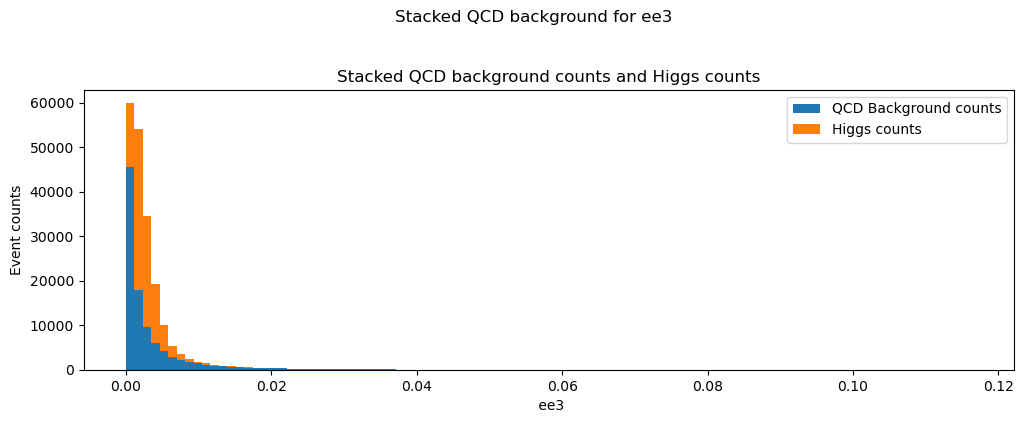

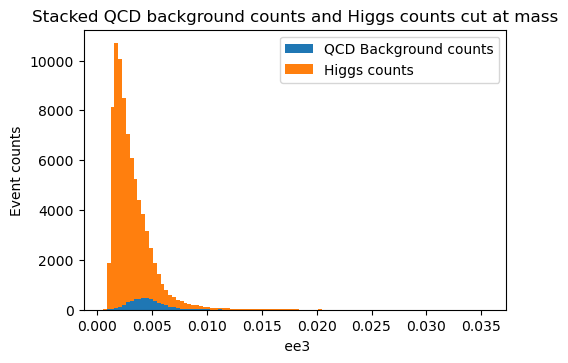

```python
plot_stacked("ee3")
```

From the 1st plot we can see that both the background data and the Higgs data have a similar spread this is not a discriminative feature as a cut on this feature would not be productive as it would throw out more Higgs than background.

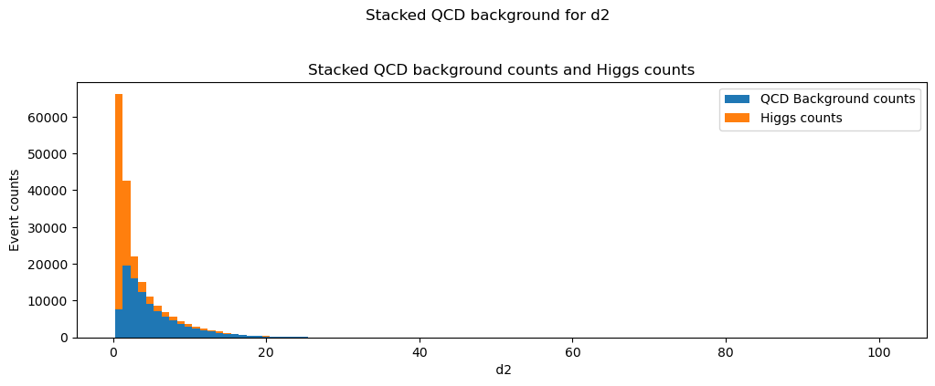

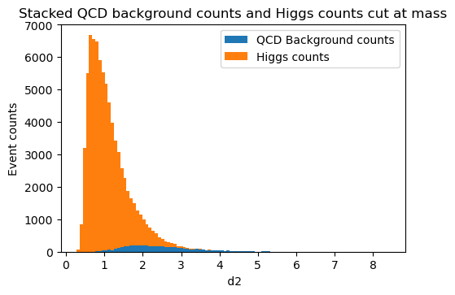

```python
plot_stacked("d2")
```

From the 1st plot we can see that both the background data and the Higgs data have a similar spread this is not a discriminative feature as a cut on this feature would not be productive as it would throw out more Higgs than background.However, after the cut at mass we see that there is some room for eliminating background values while keeping the higgs data (this is possible from d2 values of 2 to 5)

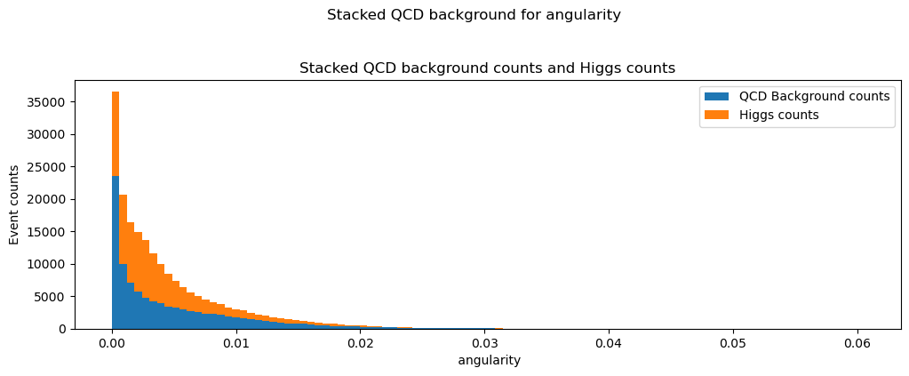

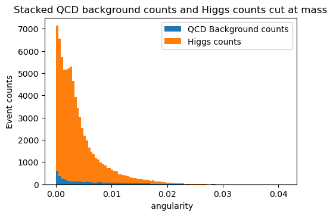

```python
plot_stacked("angularity")
```

From the 1st plot we can see that both the background data and the Higgs data have a similar spread this is not a discriminative feature as a cut on this feature would not be productive as it would throw out more Higgs than background.

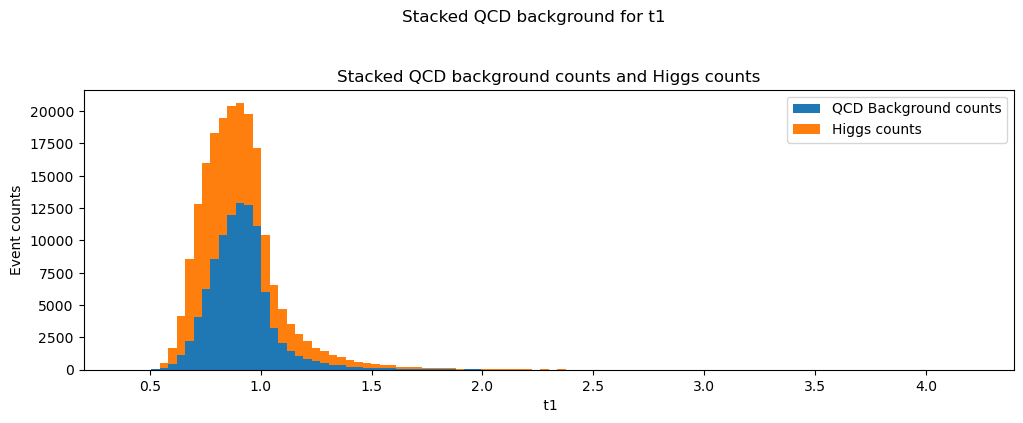

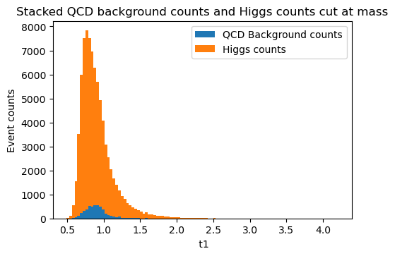

```python
plot_stacked("t1")
```

From the 1st plot we can see that both the background data and the Higgs data have a similar spread this is not a discriminative feature as a cut on this feature would not be productive as it would throw out more Higgs than background.

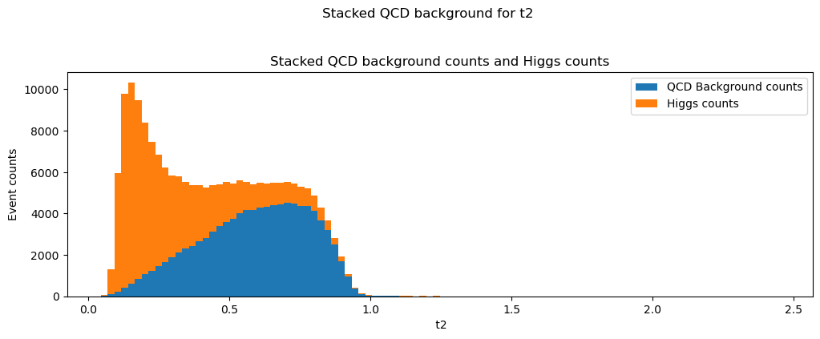

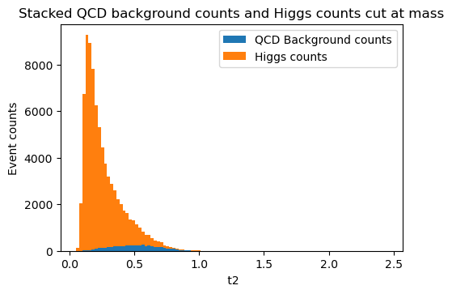

```python
plot_stacked("t2")
```

From 1st plot trying to identify if t2 is as discriminative as mass from the first plot let's eliminate t2 > .3

```python
higgs_t2 = higgs_data[(higgs_data["t2"] <= .3)]
qcd_t2 = qcd_data[(qcd_data["t2"] <= .3)]
cnt_higgs_t2 = len(higgs_t2) * (.001)
cnt_qcd_t2 = len(qcd_t2) * (.2)
stats.norm.isf(stats.poisson.sf(cnt_higgs_t2 + cnt_qcd_t2, mu = cnt_qcd_t2))
```

```
1.4528225740669432
```

the achieved significanceis not as high as mass.From the second plot that we can eliminate data from t2 = .5 to 1.0 to achieve a better significance.

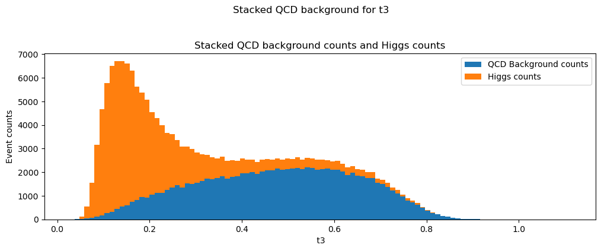

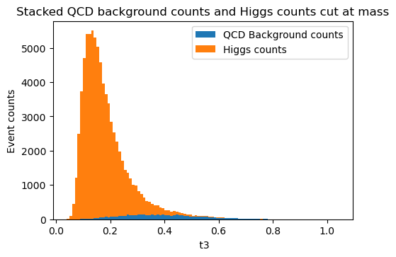

```python
plot_stacked("t3")
```

```python
higgs_t3 = higgs_data[(higgs_data["t3"] <= .3)]
qcd_t3 = qcd_data[(qcd_data["t3"] <= .3)]
cnt_higgs_t3 = len(higgs_t3) * (.001)
cnt_qcd_t3 = len(qcd_t3) * (.2)
stats.norm.isf(stats.poisson.sf(cnt_higgs_t3 + cnt_qcd_t3, mu = cnt_qcd_t3))
```

```
1.3211899178044662
```

the achieved significanceis not as high as mass.From the second plot that we can eliminate data from t3 = .3 to 1.0 to achieve a better significance.

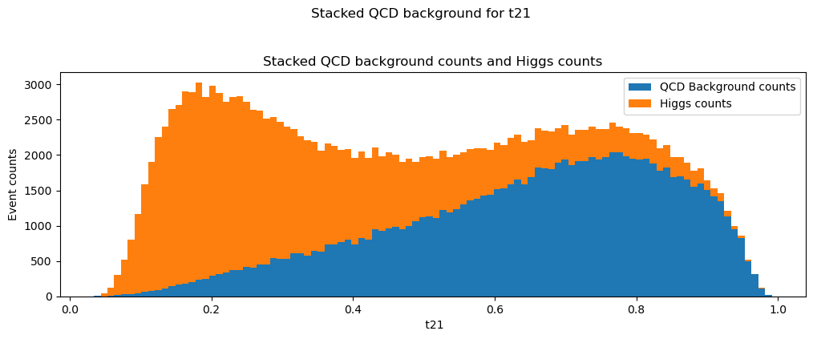

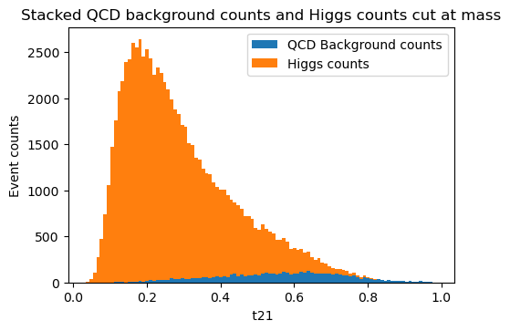

```python
plot_stacked("t21")
```

From 1st plot trying to identify if t21 is as discriminative as mass from the first plot let's eliminate t21 > .3

```python
higgs_t21 = higgs_data[(higgs_data["t21"] <= .3)]
qcd_t21 = qcd_data[(qcd_data["t21"] <= .3)]
cnt_higgs_t21 = len(higgs_t21) * (.001)
cnt_qcd_t21 = len(qcd_t21) * (.2)
stats.norm.isf(stats.poisson.sf(cnt_higgs_t21 + cnt_qcd_t21, mu = cnt_qcd_t21))
```

```
1.4703678472923785
```

the achieved significance isn't be as high as mass. From the second plot that we can eliminate data from t21 = .3 to 1.0 to achieve a better significance.

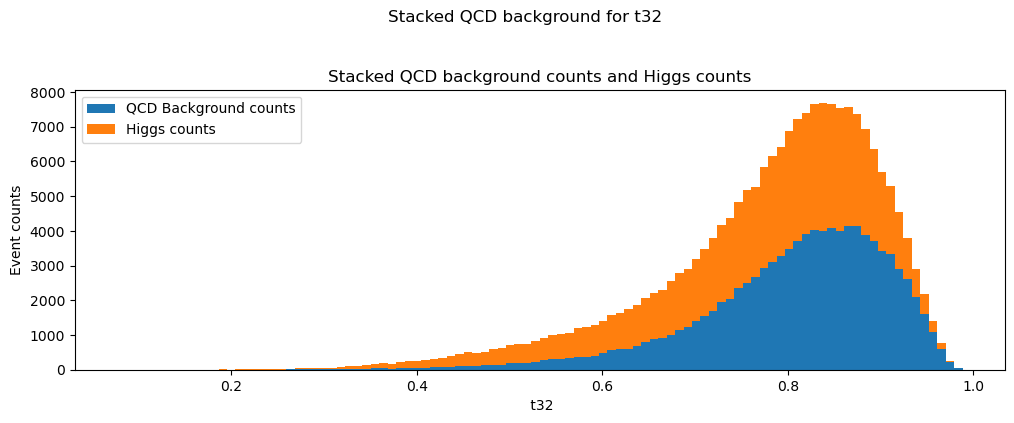

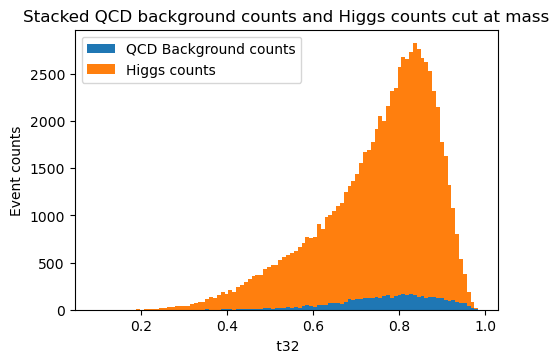

```python
plot_stacked("t32")
```

From the 1st plot we can see that both the background data and the Higgs data have a similar spread this is not a discriminative feature as a cut on this feature would not be productive as it would throw out more Higgs than background.

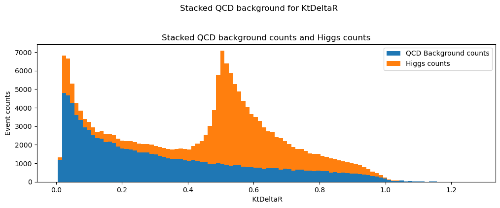

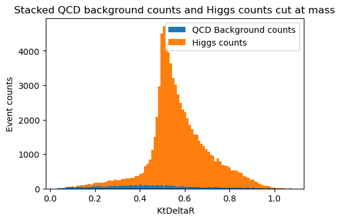

```python
plot_stacked("KtDeltaR")
```

From 1st plot trying to identify if KtDeltaR is as discriminative as mass from the first plot let's eliminate KDeltaR < .4 and KDeltaR > 0.7

```python
higgs_KDeltaR = higgs_data[(higgs_data["KtDeltaR"] >= .4) & (higgs_data["KtDeltaR"] <= .7)]
qcd_KDeltaR = qcd_data[(qcd_data["KtDeltaR"] >= .4) & (qcd_data["KtDeltaR"] <= .7)]
cnt_higgs_KDeltaR = len(higgs_KDeltaR) * (.001)
cnt_qcd_KDeltaR = len(qcd_KDeltaR) * (.2)
stats.norm.isf(stats.poisson.sf(cnt_higgs_KDeltaR + cnt_qcd_KDeltaR, mu = cnt_qcd_KDeltaR))
```

```
1.0098228504650235
```

the achieved significance isn't as high as mass.From the second plot that we can eliminate data from KDeltaR < .4 and KDeltaR > 0.7 to achieve a better significance.

Discrimanitive Features: KDeltaR, t21, t3, t2

Significance after each of the cuts:

KDeltaR - 1.0098228504650235

t21 - 1.4703678472923785

t3 - 1.3211899178044662

t2 - 1.4528225740669432

Top 2 discriminative features : t21, t2

However looking at the plots it doesn't look like any of them would be as discriminative as mass.As for mass the range of the background data compared to Higgs data is much higher than any of the other plots.However, we can use the discriminating features to furthur increase the significance.

Non-Discriminative Features: t32, t1, angularity, ee3, ee2, pt, eta, phi

Discriminative after mass cut : d2

## Problem 4

We will reduce the data using the following discriminative till we achieve a significance of greater than or equal to 5.

Let's start by eliminating the data with t21 > .3

```python
new_cut_qcd = qcd_cut3[(qcd_cut3["t21"] <= .3)]
```

```python
new_cut_higgs = higgs_cut3[(higgs_cut3["t21"] <= .3)]
```

```python
cnt_cut_higgs = len(new_cut_higgs) * (.001)
cnt_cut_higgs
```

```
48.208
```

```python
cnt_cut_qcd = len(new_cut_qcd) * (.2)
cnt_cut_qcd
```

```
80.4
```

probability of signal

```python
p = stats.poisson.sf(cnt_cut_higgs + cnt_cut_qcd, mu = cnt_cut_qcd)
p
```

```
3.753980758596789e-07
```

Significance of Signal

```python
stats.norm.isf(p)
```

```
4.947741264760235
```

Next let's eliminate data with t2 > .3

```python
new_cut_qcd = new_cut_qcd[new_cut_qcd["t2"] <= .3]
new_cut_higgs = new_cut_higgs[(new_cut_higgs["t2"] <= .3)]
cnt_cut_higgs = len(new_cut_higgs) * (.001)
cnt_cut_higgs
```

```
46.582
```

```python
cnt_cut_qcd = len(new_cut_qcd) * (.2)
cnt_cut_qcd
```

```
68.4
```

```python
p = stats.poisson.sf(cnt_cut_higgs + cnt_cut_qcd, mu = cnt_cut_qcd)
p
```

```
1.7352735169523013e-07
```

```python
stats.norm.isf(p)
```

```
5.095918345470838
```

We got the required significance to confirm our significance.

Percent of Higgs Event Eliminated

```python
100 - ((len(new_cut_higgs)/len(higgs_data)) * 100)
```

```
53.418
```

Percent of QCD Event Eliminated

```python
100 - ((len(new_cut_qcd)/len(qcd_data)) * 100)
```

```
99.658
```

The significance with no event selection was 0.711 with mass cut for mass < 120 and mass > 130 , it increased to 2.412. Then after reducing the data with t21 the significance increased to 4.947741264760235 then after reducing the data with t2 the significance increased to 5.095918345470838

### Comparison With Peter T Gwartney's Report

My lab partner Peter T Gwartney did a similar analysis on a different set of data. His set of data was once again 100k QCD background events and 100k Higgs Boson events except his events all have a transverse momentum, pT, between 1000 and 1200 where all of my events have a transverse momentum between 250 and 500.His initial significance without any cuts was 1.1282 which was higher than mine. He made several cuts to increase his significance to 4.548.This is slightly lower than 5 which is contrary to mine 5.0959 which is slightly greater than 5.The set of feature cuts found by him were angularity, t1 and t3. The set of differentiating features found by me were t21 and t2.

# Lab 8

```python
%matplotlib inline
import numpy as np
import matplotlib
import matplotlib.pyplot as plt
import scipy
from scipy import stats
import pickle
import pandas as pd

plt.rcParams["figure.figsize"] = (10,8)
```

```python
infile_qcd = open("qcd_100000_pt_250_500.pkl",'rb')
qcd_data = pickle.load(infile_qcd)
infile_higgs = open("higgs_100000_pt_250_500.pkl", 'rb')
higgs_data = pickle.load(infile_higgs)
highlumi = pd.read_hdf("data_highLumi_pt_250_500.h5")
lowlumi = pd.read_hdf("data_lowLumi_pt_250_500.h5")
```

```python
new_cut_higgs
new_cut_qcd
```

|  | pt | eta | phi | mass | ee2 | ee3 | d2 | angularity | t1 | t2 | t3 | t21 | t32 | KtDeltaR |
| --- | --- | --- | --- | --- | --- | --- | --- | --- | --- | --- | --- | --- | --- | --- |
| 91 | 396.126634 | -1.178188 | 1.482313 | 120.221352 | 0.158673 | 0.005196 | 1.300690 | 0.001786 | 0.924251 | 0.271112 | 0.228171 | 0.293332 | 0.841612 | 0.471541 |
| 485 | 406.800823 | 0.091541 | 2.499408 | 121.918836 | 0.143841 | 0.004410 | 1.481715 | 0.011083 | 0.954376 | 0.254947 | 0.240843 | 0.267135 | 0.944681 | 0.417594 |
| 777 | 472.399673 | -1.004161 | -1.162003 | 127.003292 | 0.137725 | 0.003790 | 1.450743 | 0.003243 | 0.892924 | 0.198737 | 0.173123 | 0.222569 | 0.871116 | 0.436907 |
| 1029 | 454.598637 | -0.703246 | -2.213835 | 120.693749 | 0.131232 | 0.003403 | 1.505869 | 0.003543 | 0.794995 | 0.226185 | 0.163466 | 0.284511 | 0.722710 | 0.437128 |
| 1688 | 454.261019 | 0.724770 | -1.533359 | 126.461710 | 0.138338 | 0.003236 | 1.222329 | 0.003679 | 1.567492 | 0.253390 | 0.215829 | 0.161653 | 0.851763 | 0.486284 |
| ... | ... | ... | ... | ... | ... | ... | ... | ... | ... | ... | ... | ... | ... | ... |
| 99026 | 446.983044 | -0.675909 | 2.219931 | 123.248347 | 0.146613 | 0.003486 | 1.106278 | 0.002726 | 0.978996 | 0.265083 | 0.220331 | 0.270770 | 0.831179 | 0.481186 |
| 99284 | 459.298783 | 0.167384 | -0.666554 | 125.386432 | 0.128681 | 0.003881 | 1.821545 | 0.010965 | 0.981938 | 0.263067 | 0.254590 | 0.267905 | 0.967777 | 0.367417 |
| 99307 | 418.545747 | 0.786732 | -2.515582 | 124.870164 | 0.127413 | 0.002839 | 1.372327 | 0.007967 | 0.755743 | 0.222591 | 0.193282 | 0.294533 | 0.868327 | 0.727113 |
| 99419 | 471.843819 | 0.511091 | 3.045776 | 127.290197 | 0.143790 | 0.002855 | 0.960304 | 0.002902 | 0.951506 | 0.218411 | 0.171589 | 0.229543 | 0.785623 | 0.499850 |
| 99455 | 405.647080 | -0.451195 | 0.618814 | 127.722364 | 0.164585 | 0.004470 | 1.002637 | 0.004460 | 0.915569 | 0.217511 | 0.193139 | 0.237569 | 0.887950 | 0.537002 |

342 rows × 14 columns

```python
cut_highlumi = highlumi[(highlumi["mass"] >= 120) & (highlumi["mass"] <= 130)]
cut_lowlumi = lowlumi[(lowlumi["mass"] >= 120) & (lowlumi["mass"] <= 130)]


cut_highlumi = cut_highlumi[(cut_highlumi["t21"] <= .3)]
cut_lowlumi = cut_lowlumi[(cut_lowlumi["t21"] <= .3)]


cut_highlumi = cut_highlumi[(cut_highlumi["t2"] <= .3)]
cut_lowlumi = cut_lowlumi[(cut_lowlumi["t2"] <= .3)]
```

## Part 1 - High Luminosity Data

expected yields for data

```python
qcd_base_yield = len(qcd_data) * .02
```

```python
higgs_base_yield = len(higgs_data) * .001
```

```python
qcd_sliced_yield = len(new_cut_qcd) * .02
```

```python
higgs_sliced_yield = len(new_cut_higgs) * .001
```

computing ratio

```python
qcd_base_R = (qcd_base_yield) / (qcd_base_yield + higgs_base_yield)
higgs_base_R = (higgs_base_yield) / (qcd_base_yield + higgs_base_yield)
qcd_slice_R = (qcd_sliced_yield) / (qcd_sliced_yield + higgs_sliced_yield)
higgs_slice_R = (higgs_sliced_yield) /(qcd_sliced_yield + higgs_sliced_yield)
```

function to generate plots

```python
def generate_plot(feature, lumi, lumi_sliced):
    # combined array for plotting
    base_combined = [qcd_data[f'{feature}'], higgs_data[f'{feature}']]
    sliced_combined = [new_cut_qcd[f'{feature}'], new_cut_higgs[f'{feature}']]

    # lets also compute the weights to scale the histogram heights by
    base_weights_qcd = np.ones(len(qcd_data)) * qcd_base_R * (len(lumi) / len(qcd_data))
    base_weights_higgs = np.ones(len(higgs_data)) * higgs_base_R * (len(lumi) / len(higgs_data))
    sliced_weights_qcd = np.ones(len(new_cut_qcd)) * qcd_slice_R * (len(lumi_sliced) / len(new_cut_qcd))
    sliced_weights_higgs = np.ones(len(new_cut_higgs)) * higgs_slice_R * (len(lumi_sliced) / len(new_cut_higgs))

    #plotting
    plt.subplot(2,1,1)
    plt.hist(base_combined, bins = 50, stacked = True, weights = [base_weights_qcd, base_weights_higgs], label = ['Qcd Background', 'Higgs Data'])
    plt.hist(lumi[f'{feature}'], bins = 50, stacked = True, histtype='step', color='k', linestyle='--', label='Observed Data')
    plt.title("Unsliced Data")
    plt.xlabel(f'{feature}')
    plt.ylabel("Event Counts")
    plt.legend()
    plt.show()


    plt.subplot(2,1,2)
    plt.hist(sliced_combined, bins = 50, stacked = True, weights = [sliced_weights_qcd, sliced_weights_higgs], label = ['Qcd Background', 'Higgs Data'])
    plt.hist(lumi_sliced[f'{feature}'], bins = 50, stacked = True, histtype='step', color='k', linestyle='--', label='Observed Data')
    plt.title("Sliced Data")
    plt.xlabel(f'{feature}')
    plt.ylabel("Event Counts")
    plt.legend()
    plt.show()
```

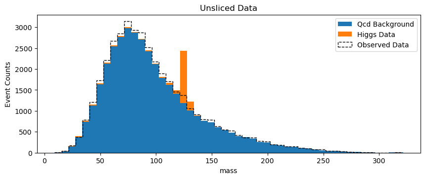

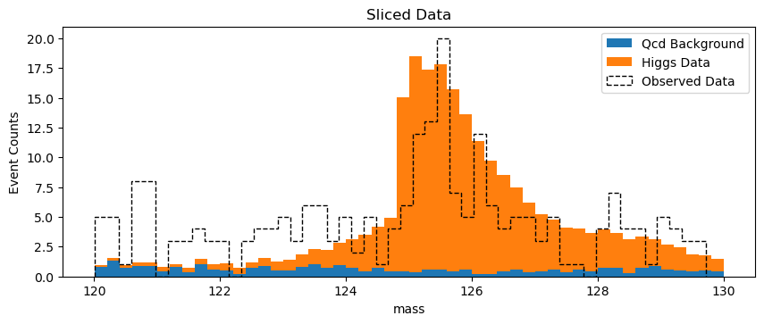

```python
generate_plot('mass', highlumi, cut_highlumi)
```

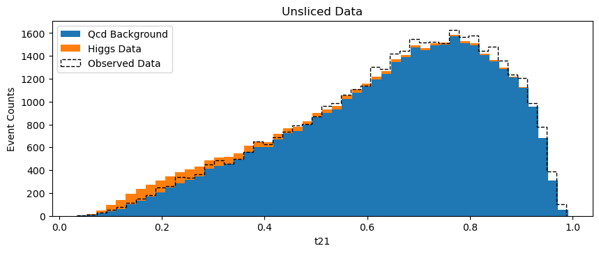

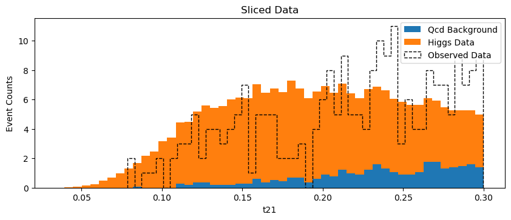

```python
generate_plot('t21', highlumi, cut_highlumi)
```

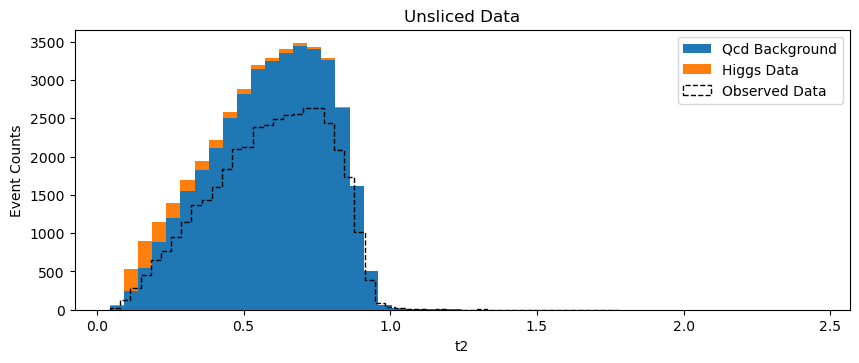

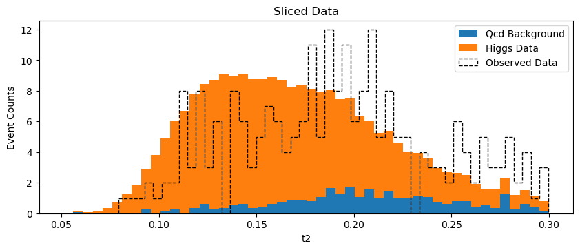

```python
generate_plot('t2', highlumi, cut_highlumi)
```

After making our cuts, we can find our expected signal-free distribution as a Poisson distribution which a mean of the ratio of remaining and initial background counts applied to the starting number of observed counts. We then find the significance of finding the counts remaining of the observation after making the same cuts if that background distribution is what we expect with no signal.

```python
parameter = len(highlumi) * (len(new_cut_qcd)/len(qcd_data))
parameter
```

```
137.97647999999998
```

```python
signal = len(cut_highlumi)
signal
```

```
234
```

```python
stats.norm.isf(stats.poisson.sf(signal, mu=parameter))
```

```
7.4759885506883625
```

The significance required to confirm a signal is 5 this is above that by a good amount

## Part 2 - Low Luminosity Data

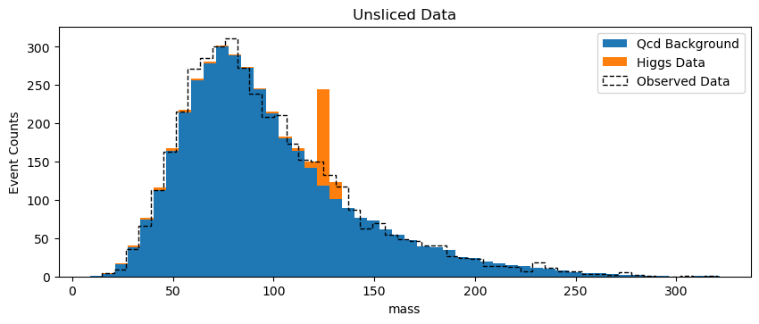

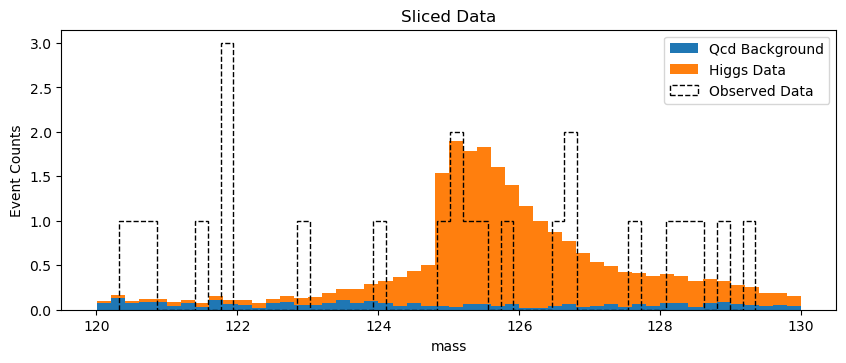

```python
generate_plot('mass', lowlumi, cut_lowlumi)
```

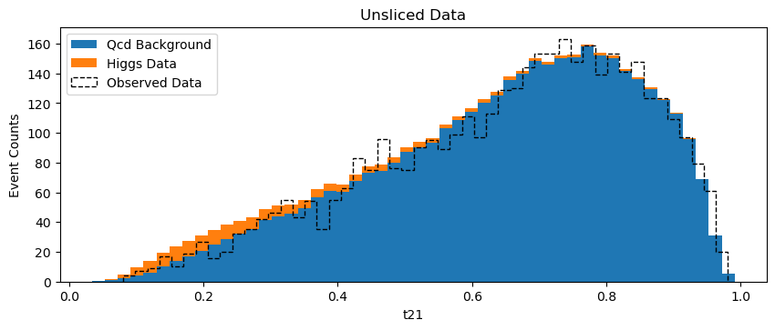

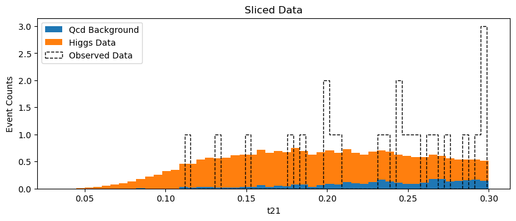

```python
generate_plot('t21', lowlumi, cut_lowlumi)
```

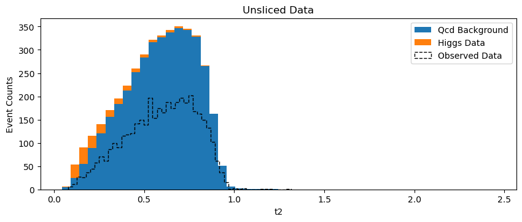

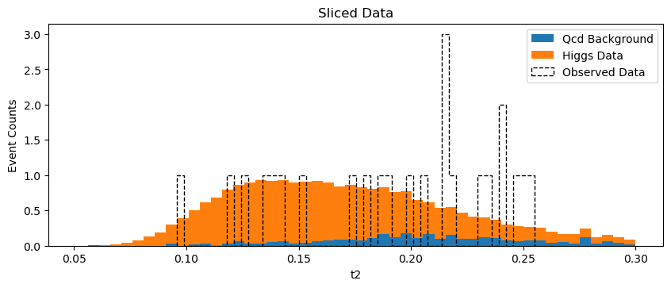

```python
generate_plot('t2', lowlumi, cut_lowlumi)
```

if the observed data is true background data then we expect that approximately the same percentage of data would be remain after splitting as we found when splitting the QCD data. However, from the plots we can see that low luminosity data doesn't appear to have any correlation with the background and the Higgs data for many of the features.

After making our cuts, we can find our expected signal-free distribution as a Poisson distribution which a mean of the ratio of remaining and initial background counts applied to the starting number of observed counts. We then find the significance of finding the counts remaining of the observation after making the same cuts if that background distribution is what we expect with no signal.

```python
parameter = len(lowlumi) * (len(new_cut_qcd)/len(qcd_data))
parameter
```

```
13.8852
```

```python
signal = len(cut_lowlumi)
signal
```

```
24
```

```python
stats.norm.isf(stats.poisson.sf(signal, mu=parameter))
```

```
2.6086334600203656
```

This is below the 5, the significance required to confirm our signal.

## Part 3 - 95% Confidence Level of signal yields

To calculate this upper limit we first must construct a 2D histogram of the data after feature selection has been applied.

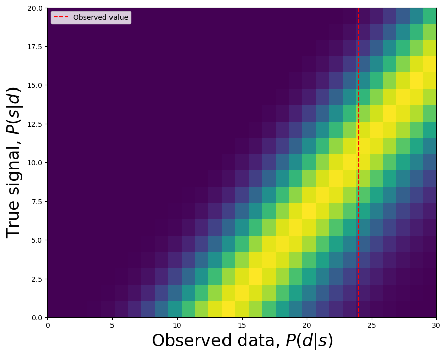

```python
draw_number = 20000000
bkgd = stats.poisson.rvs(parameter, size=draw_number)
signal = stats.uniform.rvs(loc=0, scale=70, size=draw_number)
observed = bkgd + signal
signaledges = np.linspace(0,20,20)
dataedges = np.linspace(0,30,30)

Psd, temp, temp2= np.histogram2d(observed,signal, bins=[dataedges,signaledges], density=True)

datacenters = (dataedges[:-1] + dataedges[1:]) / 2
signalcenters = (signaledges[:-1] + signaledges[1:]) / 2
plt.pcolormesh(datacenters,signalcenters,Psd.T, shading='auto')
plt.axvline(24, color='red', linestyle='--', label='Observed value')

plt.ylabel('True signal, $P(s|d)$', fontsize = 24)
plt.xlabel('Observed data, $P(d|s)$', fontsize = 24)
plt.legend()
plt.show()
```

To calculate the 95% confidence interval we try to answer the question :-

What smallest signal can I have in order to claim that 95% of the time I would have seen the Higgs provided that signal?

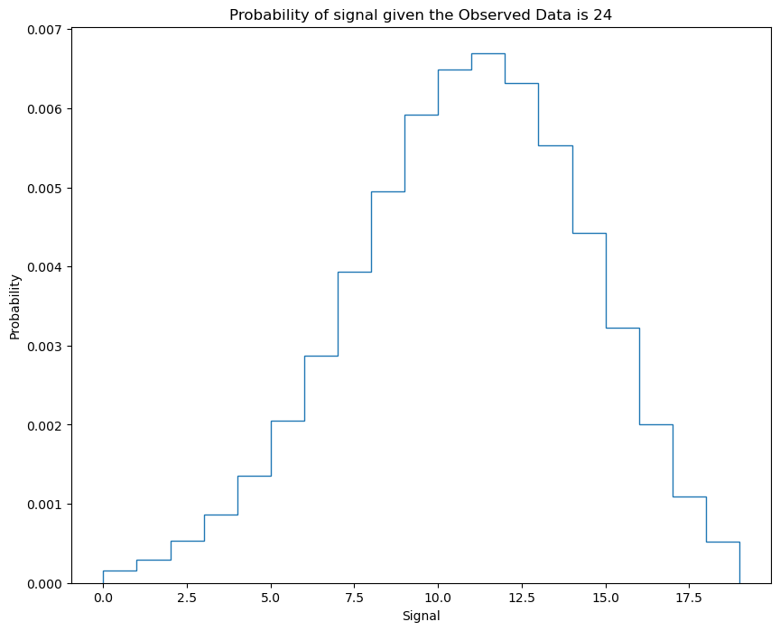

```python
plt.stairs(Psd[24])
plt.title('Probability of signal given the Observed Data is 24')
plt.xlabel('Signal')
plt.ylabel('Probability')
plt.show()
```

We can say that the probability distribution for the True signal has a poisson distribution with parameter as 11.5

So for the expected background as 14:

our expected 95% upper limit is:

```python
stats.poisson.ppf(.95, 14)
```

```
20.0
```

our observed 95% confidence level upper limit is:

```python
stats.poisson.ppf(.95, 11.5)
```

```
17.0
```

We found that our expected value is slightly higher than our found value.This is due to the fact that the parameter for the probability of true signal is slightly lower that the expected data points for low luminosity.

```python
import os
os.system('jupyter nbconvert --to html Lab6.ipynb')
```